# City Of Gainseville

Kahlil Wehmeyer - Office of Strategic Initiatives

11/4/2020

# Introduction

## What should be avoided

#### *The policing itself spawns new data, which justifies more policing*

Cathy ’O Neil, *Weapons of Math Destruction*

[**Goodhart’s Law**](https://en.wikipedia.org/wiki/Goodhart%27s_law) states that

> When a measure becomes a target, it ceases to be a good measure.

To frame it in the context of the data. If we determine Police strategy, specifically geographically, using police collected data then we run into a precocious feedback loop. Not only does the data enforce it’s own bias but it leads to a less equitable community overall.

There is plenty of research done on why report driven policing strategy is generally a bad idea. Therefore, I will shift the focus of this study more on the needs of communities to increase safety, quality of life, and equality.

# Data

The data for this exploration is based on the public *“Crime Responses”* data set which is available [here](https://data.cityofgainesville.org/Public-Safety/Crime-Responses/gvua-xt9q). The version used in this report was last updated on November 3rd, 2020.

Additional information about districts is available [here](https://data.cityofgainesville.org/Geospatial-Maps-/Color-Coded-Gainesville-Police-Zones/qzci-z4wx)

**Note**:

Data is being prepared by an external script.

- Correcting date types
- Better variable naming
- Removing extraneous variables

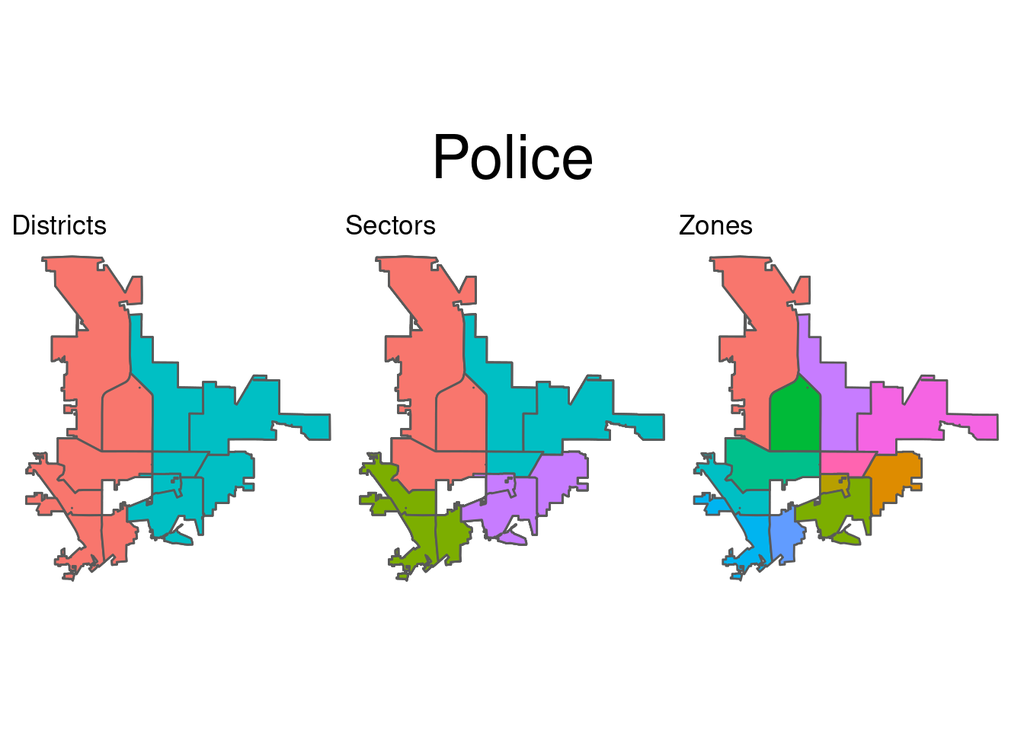

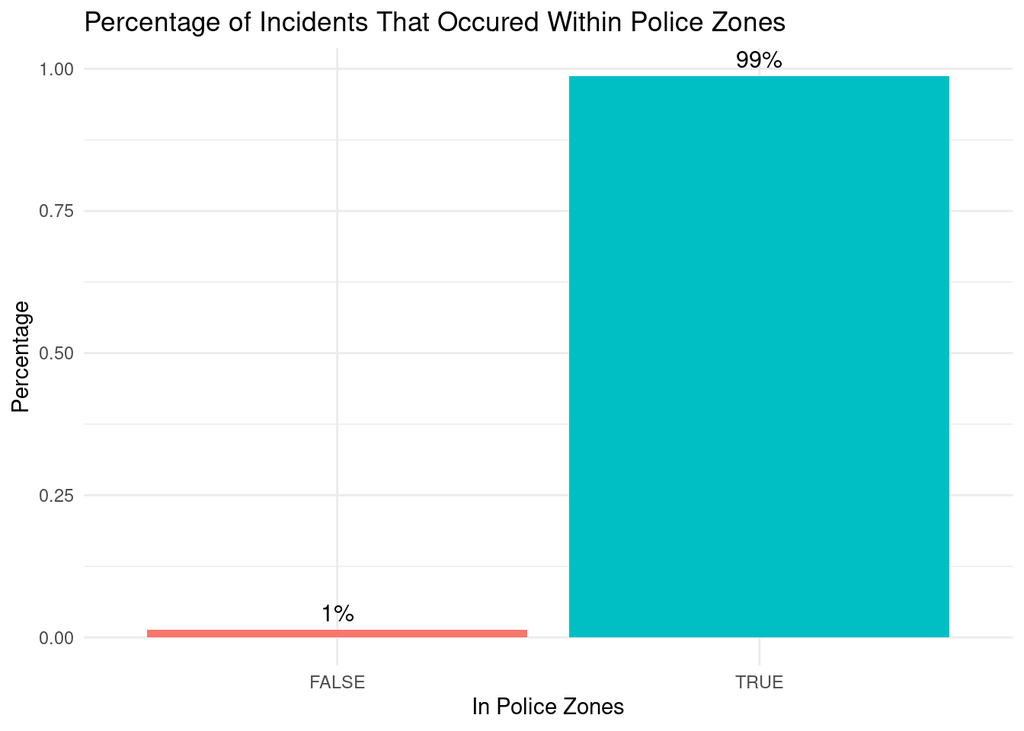

There is a small percentage of crimes that have locations outside of the given geographic areas. Some of them reside somewhere else outside of Florida, and there is a handful that are out of state. Our focus is on improving life for the immediate community, therefore those records will be discarded for the time being.

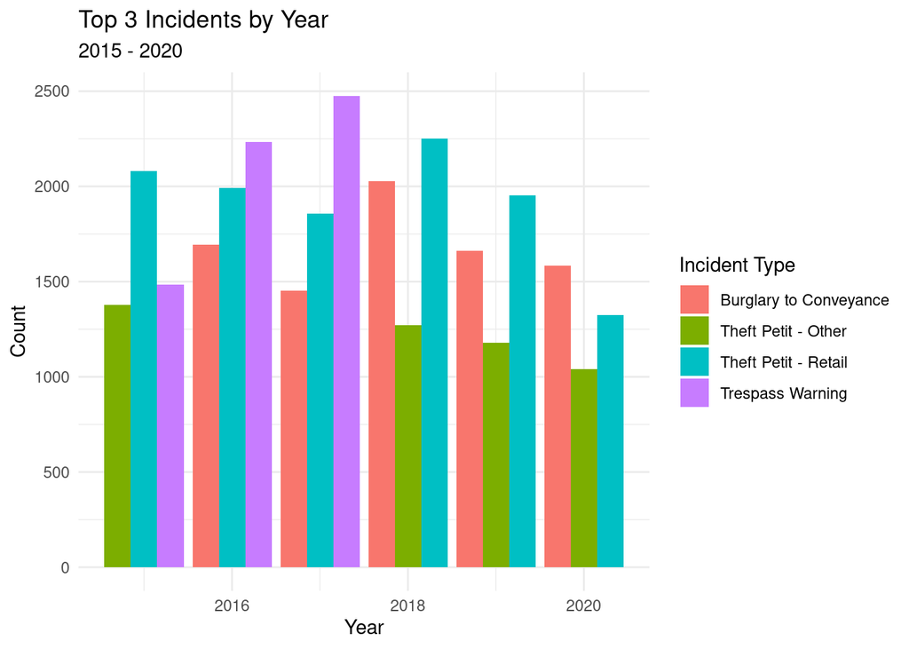

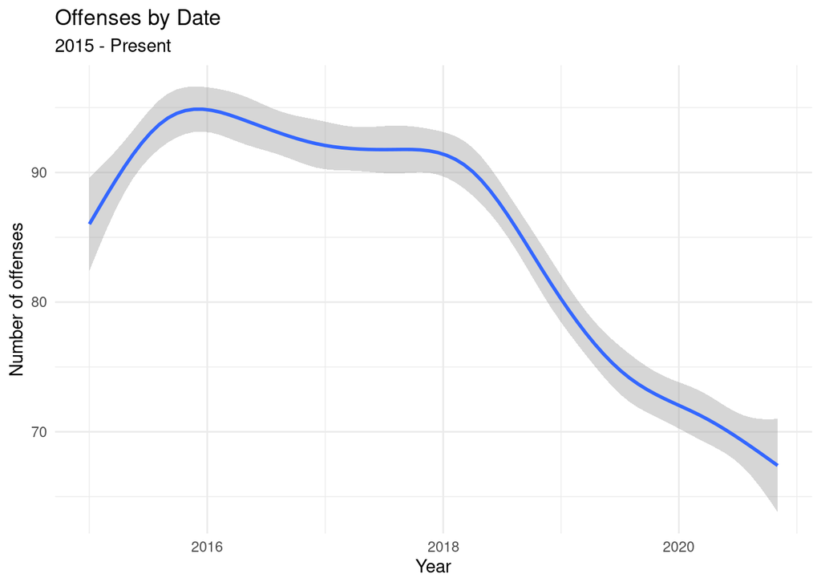

# Alpha

# Common Crimes

Here we will look at a general trend in crimes for all zones **excluding** zone Echo.

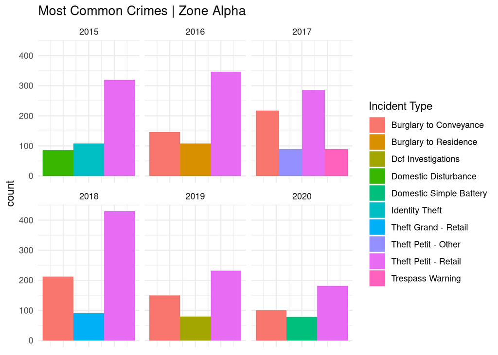

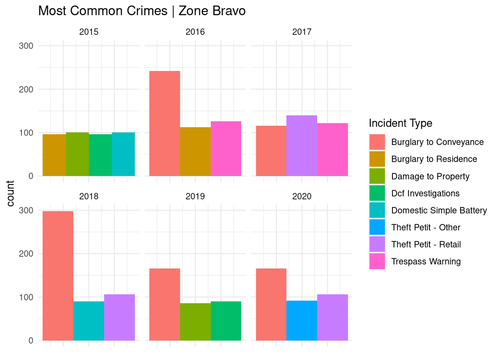

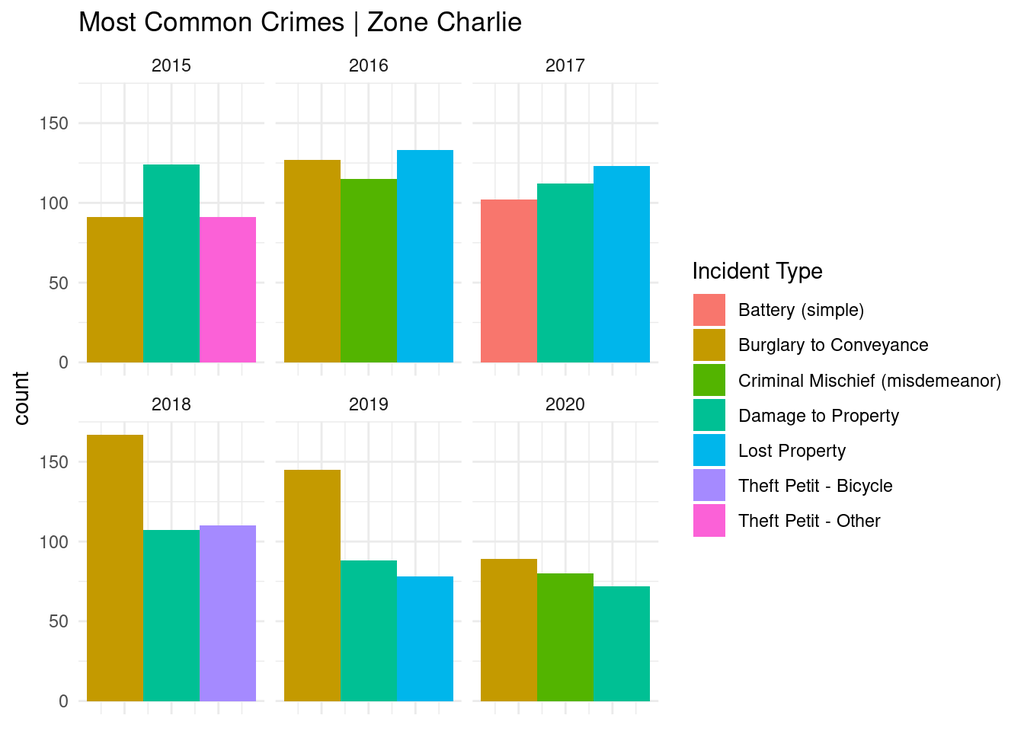

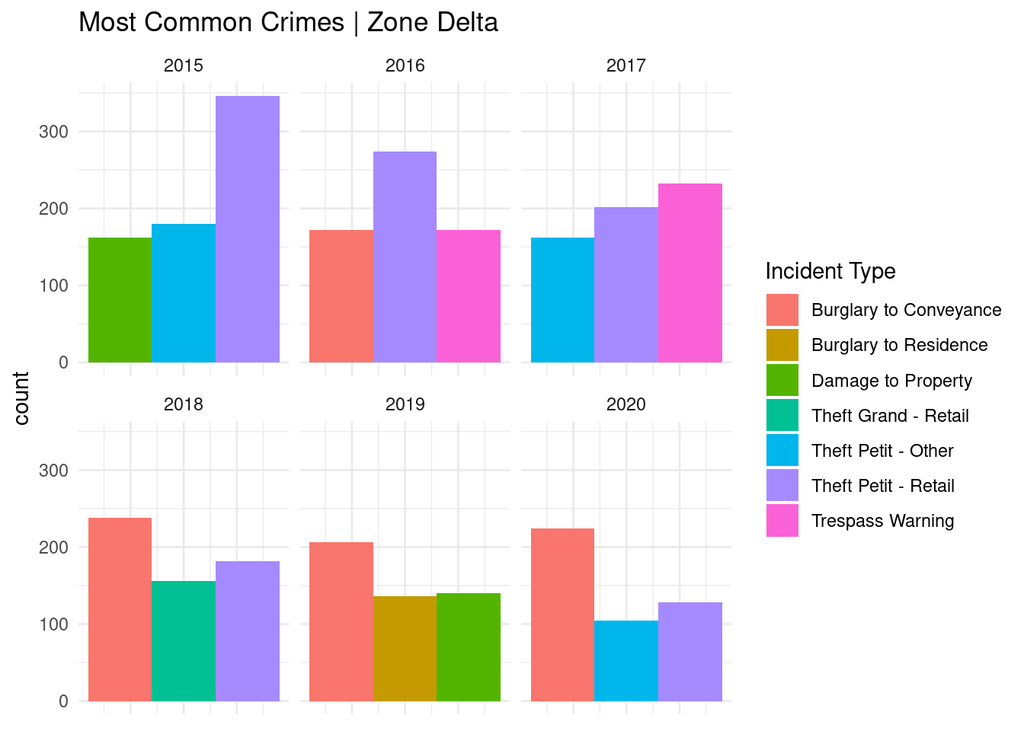

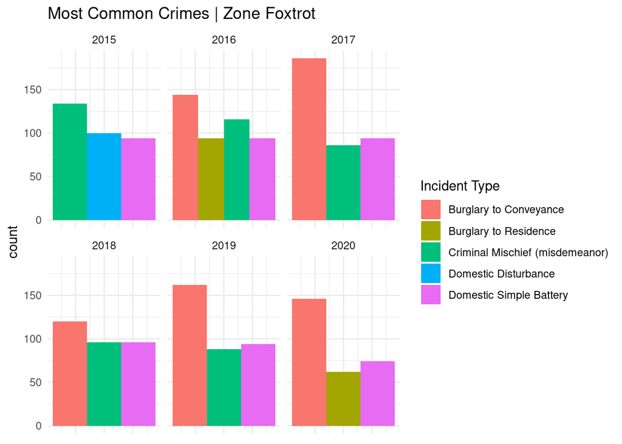

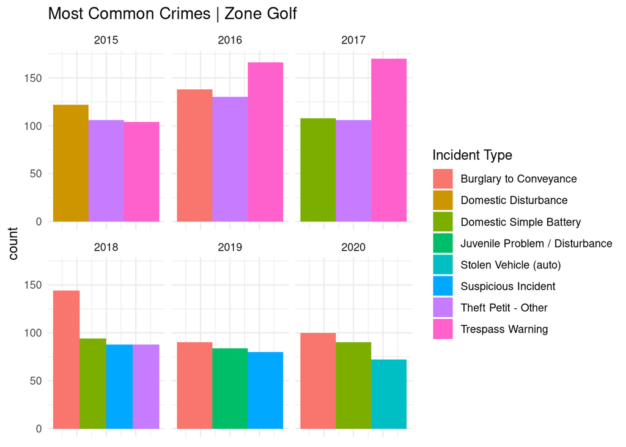

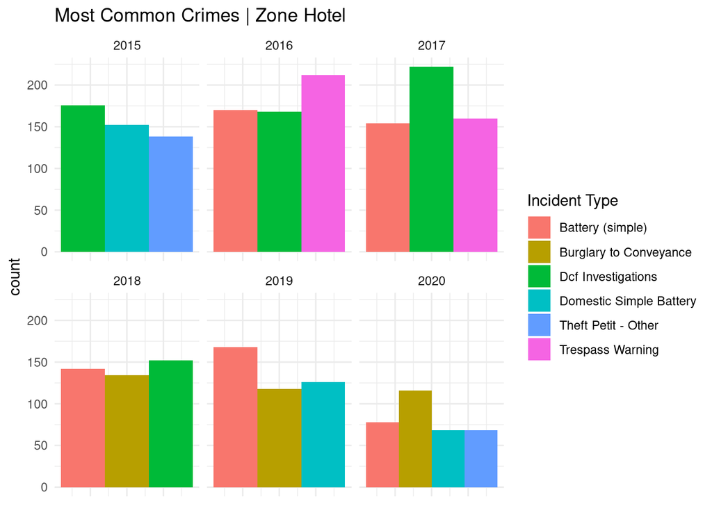

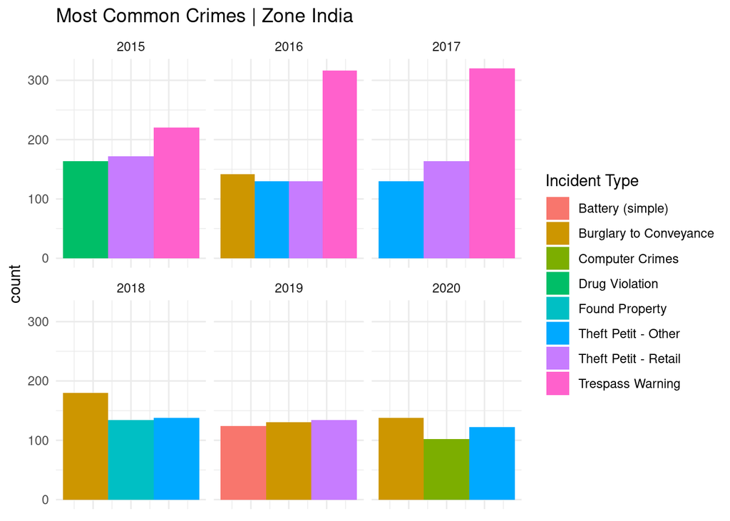

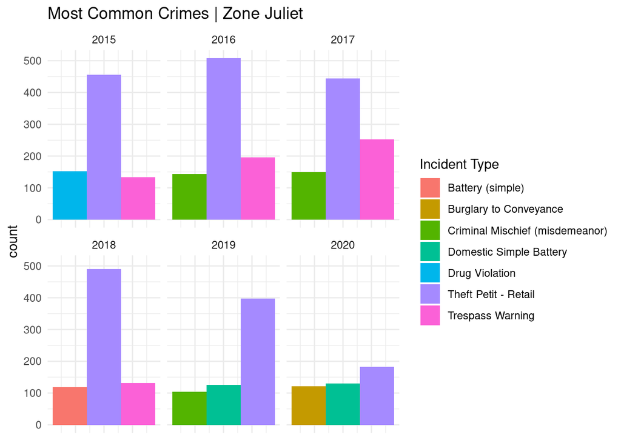

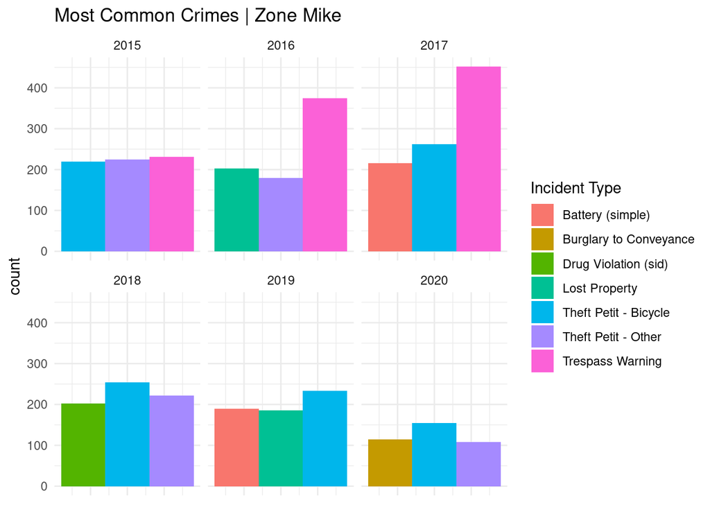

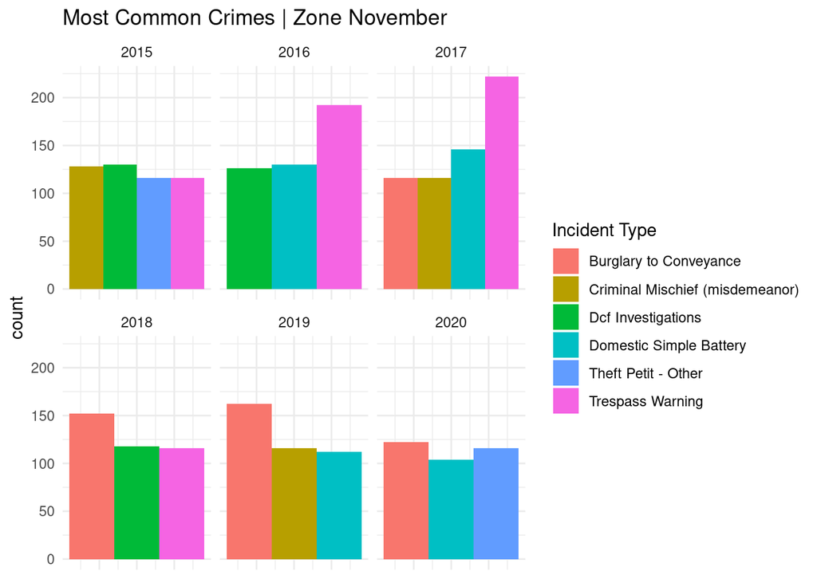

We see a general trend in that all the zones have been greatly successful in reducing the number of crimes committed in recent years. Whatever strategy has been implemented in helping reduce crime has been highly effective. However, the crime that seems to prevail in concerning numbers is Burglary to a Conveyance.

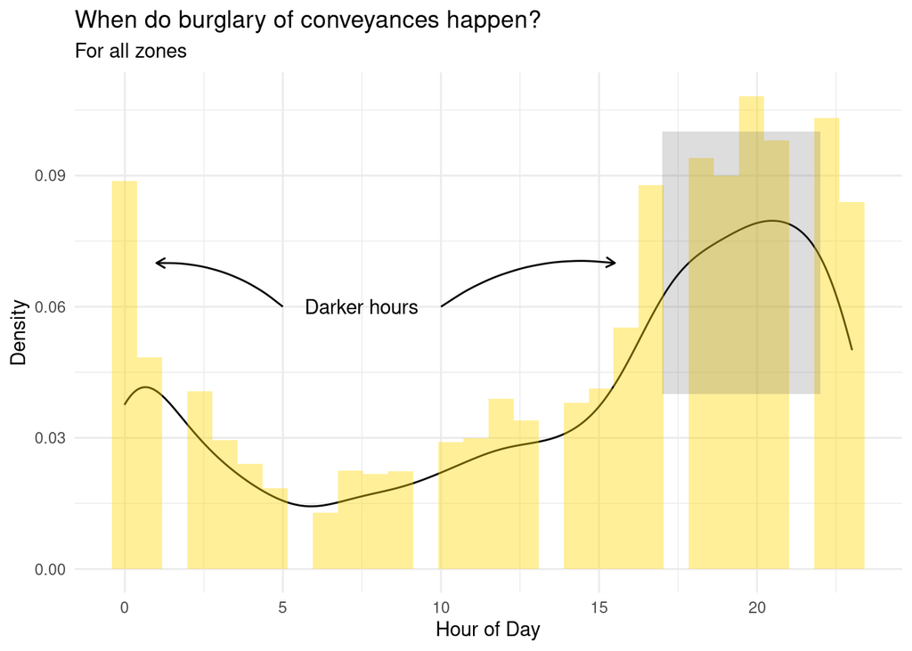

I hypothesis that if we provide better street side illumination, not only would it deter conveyance burglaries, but it would enhance the safety of pedestrians, increase civilian surveillance as well as increase driver awareness in streets, parking lots, and driveways.

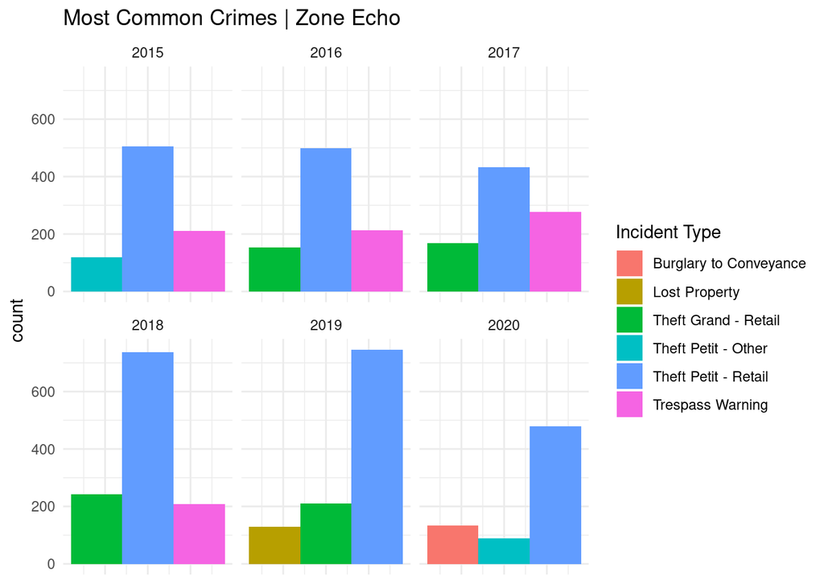

Unlike the previous zones, we see that petit retail theft has been an issue in Echo for a long time. It still is to this day. In fact, Echo makes up roughly 30% of **all** petit retail thefts. The question becomes - is there some need that is not being met which is causing the disproportionate number of these crimes? We can’t say concretely, but suspicions can be placed on impoverishment. Perhaps creating opportunities for charitable institutions to come in and provide an alternative to theft.

Regardless of the ideas on how to create a safer community for businesses, we believe it is crucial to perform a more in depth study on this zone with a goal of understanding what external factors drive the high theft numbers. Perhaps this could be an area of focus for 2021.

```
## [1] 0.2966131
```